# **Ford GoBike System User Anlysis**

## **Investigation Overview**

In this investigation, I wanted to look at the characteristics of the Ford GoBike system users in the the greater San Francisco Bay area. I wanted to understand their behaviour in terms of trevel time by daily and weekly travels, and other characteristics like age, gender, and user type.

## **Dataset Overview**

After cleaning, There were 174,760 riders' information over a period of one month in the dataset with 11 features. The features listed below are the features that were of interest to me.

- rider age
- user type
- member gender
- start time of day
- week

### **Distribution of user type**

The user type are primarily made up of two groups,the Subscribers, and the Customers. The visualization below show that the Subsribers make up a large portion of the market, while the Customers make up a smaller portion

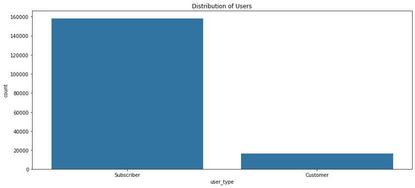

### **User Age Distribution**

The data agrees with logical reasoning, and shows that the distribution of the market is skewed to the right, with the majority of the users being between 20 and 40 years old

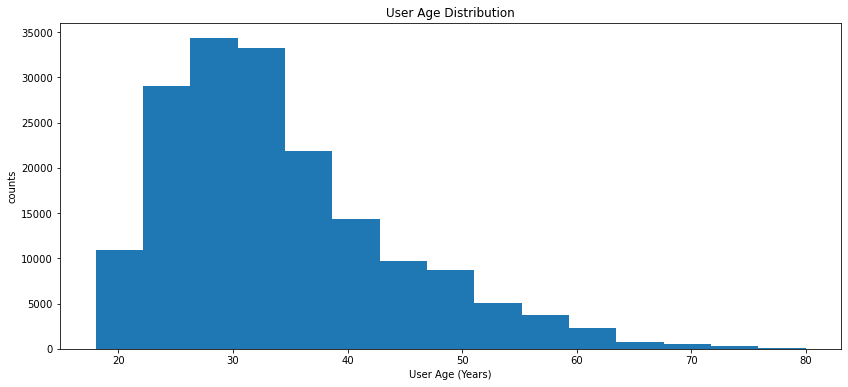

### **User Gender Distribution**

The bar chart below show the gender distribution of the users of the Ford GoBike system. The visulization below was created to provide a clearer idea into how interested the different genders are engaged in bike ride sharing. It appears that more males engage in bike riding when compared to the females, and the other gender.

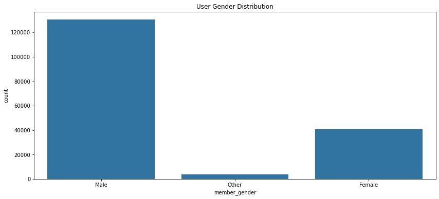

### **User Gender vs. User Type**

Generally, the user type distribution across all genders is the same. The subcribers are predominant amongst both categories

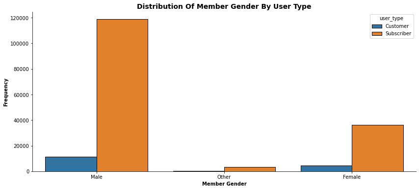

The peak times for travel is mornings, evenings, and afternoons, in that order. This distribution was also oberved across genders and user types, with a little exception to customers. Customers tend to use the product mostly in the mornings and afternoons, especially in the afternoon

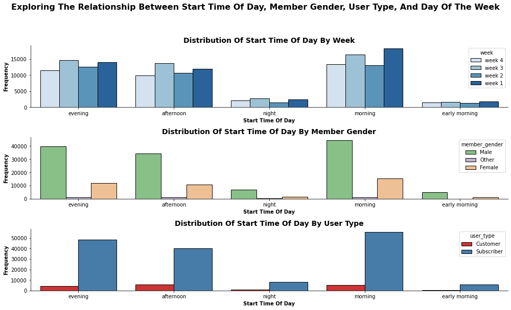

### **Conclusion**

Though the dataset provided some insight in to the age and gender distribution of the users, there are limits to how much can be derived from the insights. This is because the dataset is limited to one month of user information, which is not enough to derive a better understanding of user patterns and behaviour.